# Indicadores Instituto de Física

### Basado en el [perfil de Google Scholar para el Instituto de Física de la UdeA](https://scholar.google.com/citations?user=mxSOjTYAAAAJ)

### Diego Restrepo

### Advertencia:

El análisis de datos se ha realizado con procesos automáticos propensos a errores de programación.

### Repositorios GitHub:

- http://github.com/restrepo/gssis
- http://github.com/restrepo/indicadores

This notebook can be run directly from http://mybinder.org/restrepo/indicadores

## Cargue datos

- Formato CSV exportado del perfil de Google Scholar y extendido con DOI, Factor de Impacto, Publindex e información de la Universidad de Antioquia: Autores UdeA, y Grupos, a través del programa en python `csvreader_udea.py` del repositorio http://github.com/restrepo/gssis -> `utilities`
- Tabla de tres columnas: (Datos artículo, Citaciones, Año) copiada y pegada del perfil de Google Scholar en formato CSV (Desde la hoja de cálculo en Google Drive)
- Información de Estuduiantes de Posgrado:

  `'ESTUDIANTE','ASESOR','Estado','Fecha de ingreso','Fecha de graduación','GRUPO','PROGRAMA'`

  (Desde la hoja de cálculo en Google Drive)

## Artículos

### Metodologia

Desde el perfil de [Google Scholar](https://scholar.google.com/citations?sortby=pubdate&hl=en&user=mxSOjTYAAAAJ&view_op=list_works) para el Instituto, se exportan todos los artículos en formato csv.

Con el programa `csvreader_udea.py` en la carpeta `utilities` del repositorio de GitHub: gssis se añade la siguiente información:

- El [DOI](http://search.crossref.org), usando el título y el apellido del primer autor de la publicación
- Con del DOI se pueden verificar todos los metadatos. En particular el nombre exacto de la revista. Ejemplo: http://api.crossref.org/works/10.1103/PhysRevD.93.015012
- **Publindex**: Con el nombre exacto de la revista se obtiene la clasificación de Colciencias y su ISSN asociado desde la versión en [google spreadsheet](https://docs.google.com/spreadsheets/d/1umgapW8KOIPqmu_hyjon3n2SXbnbDlmnRnXzjUHcXHE/edit?usp=drive_web) del archivo en excel del Publindex de Colciencias para revistas homologadas. (Se carga el csv desde el código)
- Con el ISSN se obtiene el **factor de impacto** con: [búsqueda de Google](https://goo.gl/JMHmhS)
- El programa extrae los **autores de la UdeA** de la lista de autores y asocia al artículo los **Grupos de Investigación** correspondientes.

En este Notebook de Ipython además se añade la siguiente información

- **Citaciones**: [La página web con el perfil de Google Scholar](https://scholar.google.com/citations?sortby=pubdate&hl=en&user=mxSOjTYAAAAJ&view_op=list_works) muestra hasta 1000 entradas en una tabla de tres columas con la información del artículo, el número de citas y el año de publicación. Si la correspondiente tabla se copia directamente en una hoja cálculo de Google, luego puede ser cargada como un archivo `csv` desde `pandas`. El título del artículo, en la base de datos enriquecida de artículos, puede ser contrastado con la columna de información de la hoja de cáculo de citaciones para asignarle el número de citas correspondiente. De ser necesario se puede recurrir a otra información de artículo como por ejemplo: el volumen de la revista en que fue publicado
- **Área**: A cada artículo se le asigna el área teórica o experimental dependiendo del Grupo al que pertenece, teniendo en cuenta algunos casos especiales para el Grupo de Estado Sólido.
- **Estudiantes**: En la lista de autores de cada artículo se busca si contiene estudiantes de posgrado analizando la fecha del artículo con relación al año de ingreso y de graduación más uno, del estudiante de posgrado localizado.
- Obtenemos los **artículos publicados**, filtrando los artículos a los que fue posible asignarles el ISSN o el DOI. Se crea una muestra adcional con las artículos publicados en los últimos cinco años.

El resultado final esta en el repositorio de GitHub: [restrepo/indicadores](https://github.com/restrepo/gssis/blob/master/utilities/), en el archivo `newcitations_extended.csv`.

#### Missing UdeA author/

```python
for i in df[df.Title.str.contains('Collider aspects of flavor physics at high Q')].index:
    df.Group.ix[i]='GFIF: Grupo de Fenomenología de Interacciones Fundamentales'
    df['Institution Authors'].ix[i]='Restrepo Quintero Diego Alejandro'

for i in df[df.Title.str.contains('The hunt for new physics at the Large Hadron Collider')].index:
    df.Group.ix[i]='GFIF: Grupo de Fenomenología de Interacciones Fundamentales'
    df['Institution Authors'].ix[i]='Restrepo Quintero Diego Alejandro'
```

### Incluyendo citaciones...

Citaciones esperadas: 12994 (Feb. 2016). Obtenidas:

```python
df.Cites.sum()
```

```
12975
```

```python
#Todo: 'Año Graduación' :USAR PARA FILTRAR Profesores cuando eran estudiantes
config_inf={'DEBUG':False} #Development mode
config_inf['Years']=range(1995,2016)
#Convertir YYYY-S a YYYY, e.g 2015-1 a 2015
dfe['Año de ingreso']=dfe['Fecha de ingreso'].replace('','0').replace('null','0').str.replace('-1','').str.replace('-2','').astype('int')
dfe['Año de graduación']=dfe['Fecha de graduación'].replace('','0').replace('null','0').str.replace('-1','').str.replace('-2','').astype('int')#.values
#dfe['Año de graduación'].values
#dfei=dfe[dfe['Año de ingreso']>=config_inf['Years'][0]].reset_index(drop=True)
#dfei=dfe[dfe['Año de graduación']>=config_inf['Years'][0]].reset_index(drop=True)
dfei=dfe[dfe.Estado!='Desertor'].reset_index(drop=True)
#Estudiantes
student_coauthor=1 #until 2 years after graduation date
dfd=pd.Series()
art_est=pd.Series()
dfd['D']=dfei[dfei.PROGRAMA=='Doctorado'].reset_index(drop=True)
dfd['M']=dfei[dfei.PROGRAMA=='Maestría'].reset_index(drop=True)
dfd['P']=dfei
for k in dfd.keys():
    art_est[k]=pd.DataFrame()
    if k=='P': est_p=pd.DataFrame()
#phdest=pd.DataFrame()
    dfd[k]['Author']=''
    for i in range(dfd[k].shape[0]):
        est=re.sub('\s+$','',re.sub('^\s+','',dfd[k]['ESTUDIANTE'][i])).replace('  ',' ').split(' ')
        if len(est)==4:
            dfd[k]['Author'][i]='%s, %s' %(plainstr(est[2]),est[0][0])
        elif len(est)==3:
            dfd[k]['Author'][i]='%s, %s' %(plainstr(est[1]),est[0][0])
        elif len(est)==2:
            dfd[k]['Author'][i]='%s, %s' %(plainstr(est[1]),est[0][0])
        else:
            dfd[k]['Author'][i]='%s, %s' %(plainstr(est[-1]),est[0][0])
        #special cases
        if dfd[k]['Author'][i]=='Duque, C':
            dfd[k]['Author'][i]='Duque, CM'
        if dfd[k]['Author'][i]=='Restrepo, J':
            dfd[k]['Author'][i]='Restrepo Cuartas, J'

        ma=df[df['Autor(es)'].str.contains(dfd[k]['Author'][i])]
        if ma.shape[0]>0: #Check also Group
            ma['Estudiante']=dfd[k]['Author'][i]
            ma['Estudiante_full']=dfd[k]['ESTUDIANTE'][i]
            ma['Año Graduación']=dfd[k]['Año de graduación'][i]
            ma=ma[ma['Año']>=dfd[k]['Año de ingreso'][i]]
            if dfd[k]['Fecha de graduación'][i]!='':
                ya=dfd[k]['Año de graduación'][i]+student_coauthor
                #ya=eval(re.sub('-[12]$','',dfd[k]['Fecha de graduación'][i]))+student_coauthor
                ma=ma[ma['Año']<=ya]

        art_est[k]=art_est[k].append(ma)

    if k=='P':
        est_p=art_est[k].drop_duplicates()
    art_est[k]=art_est[k].drop_duplicates().reset_index(True).sort_values('Año',ascending=False).reset_index(drop=True)
    art_est[k]=art_est[k][['Tipo','Artículo','Autor(es)','Año Graduación','Año','Revista','ISSN','Estudiante']]

df['Estudiantes']='Desconocido'
for i in est_p.index:
    lst=sorted(np.unique(est_p['Estudiante_full'][i]))
    sep=''
    if len(lst)>1: sep='; '
    lst=sep.join(lst)
    lst=lst.replace('John Jairo Zuluaga Quintero; Jorge Ivan Zuluaga Callejas','Jorge Ivan Zuluaga Callejas')
    lst=lst.replace('Johan Mazo-Zuluaga; Jorge Ivan Zuluaga Callejas','Jorge Ivan Zuluaga Callejas')
    lst=lst.replace('Johan Mazo-Zuluaga; Juan Pablo Restrepo Cuartas','Johan Mazo-Zuluaga')
    df['Estudiantes'][i]=lst
    #publicadas['Año Graduación'][i]=est_p.sort_values('Año Graduación',ascending=False\
    #                                          )['Año Graduación'][i].reset_index(drop=True)[:-1][0]
```

### Datos a analizar del TOTAL en Google Scholar:

```python
dfp=pd.DataFrame()
dfp.append({'TOTAL':df.shape[0],'Publicadas':publicadas.shape[0],\
            'Publicadas últimos 5 años':publicadas5.shape[0]},ignore_index=True)
```

|  | Publicadas | Publicadas últimos 5 años | TOTAL |
| --- | --- | --- | --- |
| 0 | 952 | 348 | 1037 |

# Resultados

## Resultados sobre número de publicaciones

En el plano: número de artículos en función del año. Se añade la información del número de autores total de la UdeA que participan en los artículos

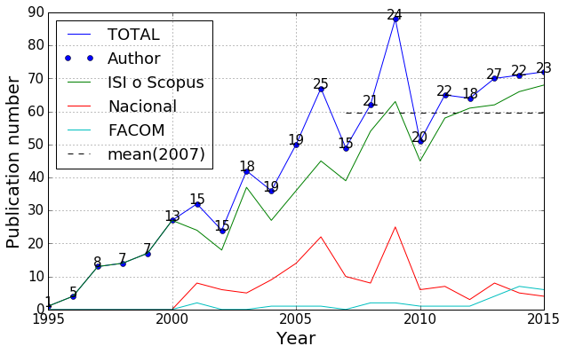

```python
plt.plot(rdf.year,rdf.articles,label='TOTAL')
plt.plot(rdf.year,rdf.articles,'bo',label='Author')
plt.plot(rdf.year,rdf.isi_o_scopus,label='ISI o Scopus')
plt.plot(rdf.year,rdf.nacional,label='Nacional')
plt.plot(rdf.year,rdf.facom,label=u'FACOM')
plt.hlines(rdf[rdf.year>2007].isi_o_scopus.mean(),2007,rdf.year.values[0],linestyles='dashed',label='mean(2007)')
plt.legend(loc='best')
for i in range(len(rdf.year)):
    plt.annotate(str(int(rdf.UdeA_author[i])),xy=(rdf.year[i],rdf.articles[i]),\
                 horizontalalignment='center',size=15)
plt.xlabel('Year',size=20)
plt.ylabel('Publication number',size=20)
plt.grid()
```

En los picos hay una mezcla de profesores y estudiantes...

2009 Team

```python
y=2009
values=np.unique(publicadas[publicadas['Año']==y]['Institution Authors'].fillna('NN').str.split('; ').sum())
pd.Series(dict(zip(range(values.shape[0]), values)))
```

```
0                Arnache Olmos Óscar L.
1            Barrera Ramírez John Fredy
2              Barrero Meneses César A.
3                Carlos Duque Echeverri
4                          Girata Doris
5                   Henao Henao Rodrigo
6            Jaramillo Arango Daniel E.
7                Mahecha Gómez Jorge E.
8                    Mazo Zuluaga Johan
9                Mira Agudelo Alejandro
10              Morales Aramburo Álvaro
11                         Nardi Enrico
12           Osorio Guillén Jorge Mario
13                   Osorio Vélez Jaime
14      Ponce Gutiérrez William Alberto
15                          Páez Manuel
16             Restrepo Cárdenas Johans
17    Restrepo Quintero Diego Alejandro
18           Reyes Gómez Ernesto Amador
19          Rodríguez Rey Boris Anghelo
20            Rueda Muñoz Edgar Alberto
21               Sanz Vicario José Luis
22                  Zapata Noreña Oscar
23          Zuluaga Callejas Jorge Iván
dtype: object
```

2013 Team

```python
y=2013
values=np.unique(publicadas[publicadas['Año']==y]['Institution Authors'].fillna('NN').str.split('; ').sum())
pd.Series(dict(zip(range(values.shape[0]), values)))
```

```
0                Arnache Olmos Óscar L.
1            Barrera Ramírez John Fredy
2              Barrero Meneses César A.
3                Carlos Duque Echeverri
4               Cuartas Restrepo Pablo
5             Ferrín Vázquez Ignacio R.
6                   Henao Henao Rodrigo
7               José David Ruíz Álvarez
8                    Mazo Zuluaga Johan
9                Mira Agudelo Alejandro
10              Morales Aramburo Álvaro
11                                   NN
12                         Nardi Enrico
13           Osorio Guillén Jorge Mario
14                   Osorio Vélez Jaime
15            Pachón Contreras Leonardo
16      Ponce Gutiérrez William Alberto
17                          Páez Manuel
18             Restrepo Cárdenas Johans
19    Restrepo Quintero Diego Alejandro
20           Reyes Gómez Ernesto Amador
21          Rodríguez Rey Boris Anghelo
22                  Romano Antonio Enea
23            Rueda Muñoz Edgar Alberto
24               Sanz Vicario José Luis
25                  Zapata Noreña Oscar
26          Zuluaga Callejas Jorge Iván
dtype: object
```

O en términos del número de estudiantes de posgrado en la lista de autores

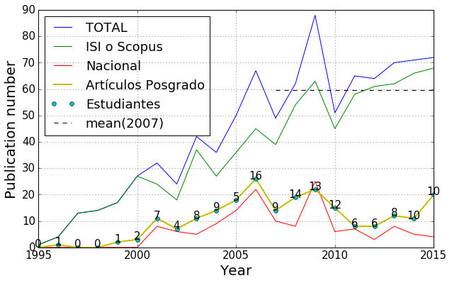

```python
plt.plot(rdf.year,rdf.articles,label='TOTAL')
plt.plot(rdf.year,rdf.isi_o_scopus,label='ISI o Scopus')
plt.plot(rdf.year,rdf.nacional,label='Nacional')
plt.plot(rdf.year,rdf.art_posgrado,'y-',lw=2,label=u'Artículos Posgrado')
plt.plot(rdf.year,rdf.art_posgrado,'co',lw=2,label='Estudiantes')
plt.hlines(rdf[rdf.year>2007].isi_o_scopus.mean(),2007,rdf.year.values[0],linestyles='dashed',label='mean(2007)')
plt.legend(loc='best')
for i in range(len(rdf.year)):
    plt.annotate(str(int(rdf.UdeA_estudiante[i])),xy=(rdf.year[i],rdf.art_posgrado[i]),\
                 horizontalalignment='center',size=15)
plt.xlabel('Year',size=20)
plt.ylabel('Publication number',size=20)
plt.grid()
```

2009 Student's Team

```python
y=2009
values=np.unique(publicadas[np.logical_and(publicadas.Year==y,publicadas.Estudiantes!='')].Estudiantes.str.split('; ').sum())
pd.Series(dict(zip(range(values.shape[0]), values)))
```

```
0               Ana Maria Calle Arcila
1          Carlos A. Vargas Castrillón
2              Carlos Andrés Vera Ciro
3                          Desconocido
4            Edgar Alberto Rueda Muñoz
5      Francisco Eugenio López Giraldo
6            Guillermo Miranda Pedraza
7     Jeaneth Patricia Urquijo Morales
8                   Johan Mazo-Zuluaga
9     Johana Alexandra Herrera Ruales
10         Oscar Alberto Zapata Noreña
11        Ricardo León Restrepo Arango
12       Richard H. Benavides Palacios
13              Yithsbey Giraldo Usuga
dtype: object
```

#### Observación

En los picos se nota un incremento en la participación de estudiantes, sobre todo en revistas nacionales (¿Congresos?)

Miremos entonces los Grupos

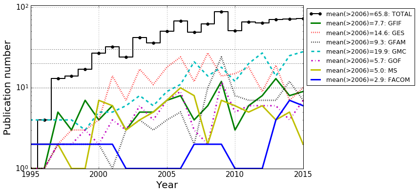

```python
#http://stackoverflow.com/a/15191183/2268280
plt.step(rdf.year,rdf.articles,'ko',lw=2,label='mean(>2006)=%.1F: TOTAL'  %rdf[rdf.year>2006].articles.mean(), where='mid')
GT=np.zeros(21)
plt.xscale('linear')
plt.yscale('log')
for g in grupos:
    GT=GT+rdf[g]
    #drawstyle='steps-mid',
    plt.plot(rdf.year,rdf[g],s[g],lw=3,label=u'mean(>2006)=%.1F: %s'  %( rdf[rdf.year>2006][g].mean(),g ) )
    #plt.semilogy(rdf.year,rdf[g],'k.',lw=2)

#plt.semilogy(rdf.year,GT ,label='Suma')    #crosscheck
plt.hlines(10,1995,2015,linestyles=':')
plt.hlines(20,1995,2015,linestyles=':')
plt.hlines(30,1995,2015,linestyles=':')
plt.ylim(1,105)
plt.legend(bbox_to_anchor=(1.42, 1),loc='upper right',fontsize='small')
plt.xlabel('Year',size=20)
plt.ylabel('Publication number',size=20)
plt.grid()
```

## Resultados Por Grupos de Investigación

#### Histórico

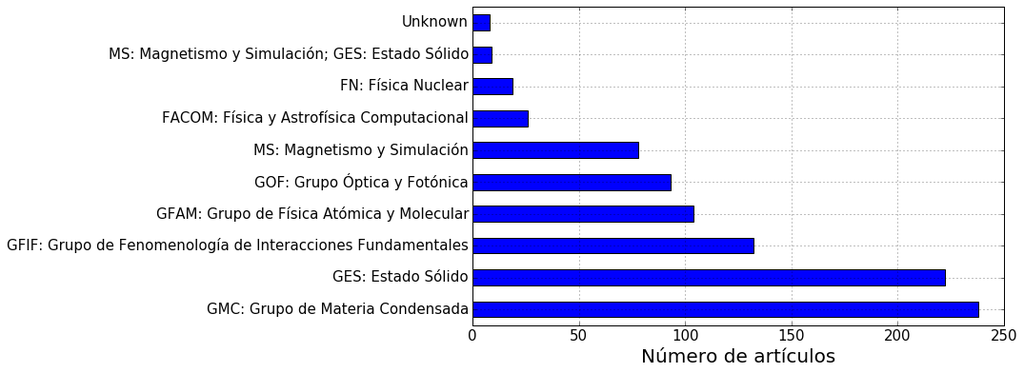

```python
publicadas['Grupo'].value_counts()[:10].plot(kind='barh', rot=0, grid=True)
plt.xlabel(u'Número de artículos',size=20)
```

#### Últimos cinco años

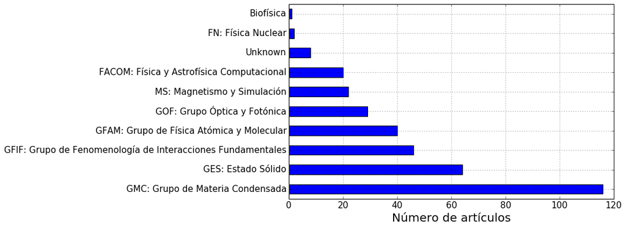

```python
publicadas5['Grupo'].value_counts()[:10].plot(kind='barh', rot=0,grid=True)
plt.xlabel(u'Número de artículos',size=20)
```

### Conclusión

Se ha alcanzado un valor asintótico, no solo en el número total, sino también en general en los grupos

## Resultados por Áreas

#### Histórico

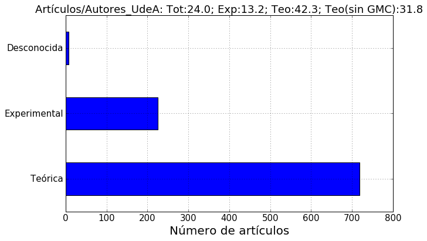

```python
Tot=publicadas.shape[0]/np.unique(publicadas['Institution Authors'].fillna('NN').str.split('; ').sum()).shape[0]
p=publicadas['Area'].value_counts()
at=np.unique(publicadas[publicadas.Area=='Teórica']['Institution Authors'].fillna('NN').str.split('; ').sum()).shape[0]
ae=np.unique(publicadas[publicadas.Area=='Experimental']['Institution Authors'].fillna('NN').str.split('; ').sum()).shape[0]
gmc=publicadas[publicadas.Grupo.str.contains('GMC')].shape[0]
publicadas['Area'].value_counts().plot(kind='barh', rot=0, grid=True)
plt.title(u'Artículos/Autores_UdeA: Tot:%0.1f; Exp:%0.1f; Teo:%0.1f; Teo(sin GMC):%0.1f' %(Tot, p.Experimental/float(ae),p['Teórica']/float(ae),\
                                                               (p['Teórica']-gmc)/float(ae-2) ) )
plt.xlabel(u'Número de artículos',size=20)
```

#### Últimos 5 años:

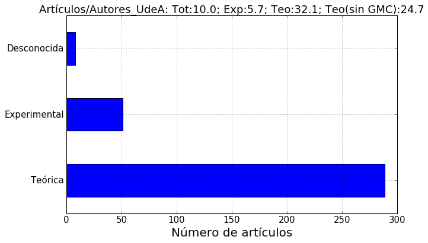

```python
Tot=publicadas5.shape[0]/np.unique(publicadas5['Institution Authors'].fillna('NN').str.split('; ').sum()).shape[0]
p=publicadas5['Area'].value_counts()
at=np.unique(publicadas5[publicadas5.Area=='Teórica']['Institution Authors'].fillna('NN').str.split('; ').sum()).shape[0]
ae=np.unique(publicadas5[publicadas5.Area=='Experimental']['Institution Authors'].fillna('NN').str.split('; ').sum()).shape[0]
gmc=publicadas5[publicadas5.Grupo.str.contains('GMC')].shape[0]
publicadas5['Area'].value_counts().plot(kind='barh', rot=0, grid=True)
plt.title(u'Artículos/Autores_UdeA: Tot:%0.1f; Exp:%0.1f; Teo:%0.1f; Teo(sin GMC):%0.1f' %(Tot, p.Experimental/float(ae),p['Teórica']/float(ae),\
                                                               (p['Teórica']-gmc)/float(ae-2) ) )
plt.xlabel(u'Número de artículos',size=20)
```

```python
pd.DataFrame().append(\
  {'Artículos por autor por año':'%0.1f' %(Tot/5),\
  'Experimental':'%0.1f' %(p.Experimental/float(ae)/5),\
  'Teórica':'%0.1f' %(p['Teórica']/float(ae)/5),\
  'Teórica sin GMC':'%0.1f' %( (p['Teórica']-publicadas5[publicadas5.Grupo.str.contains('GMC')].shape[0]\
                               )/float(ae)/5)},ignore_index=True)
#(Tot, p.Experimental/float(ae),p['Teórica']/float(ae), (p['Teórica']-gmc)/float(ae-2) )
```

|  | Artículos por autor por año | Experimental | Teórica | Teórica sin GMC |
| --- | --- | --- | --- | --- |
| 0 | 2.0 | 1.1 | 6.4 | 3.8 |

#### Conclusión

En teoría se produce más

## Resultados de autores UdeA

Primeros 15 y sólo durante su afiliación a la UdeA

#### Histórico

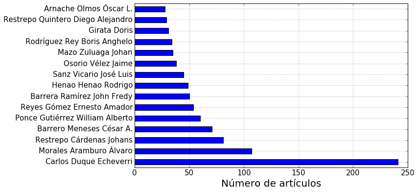

```python
publifull['UdeA_Author'].value_counts()[:15].plot(kind='barh', rot=0, grid=True)
plt.xlabel(u'Número de artículos',size=20)
```

#### Últimos cinco años

```
(1, 121)
```

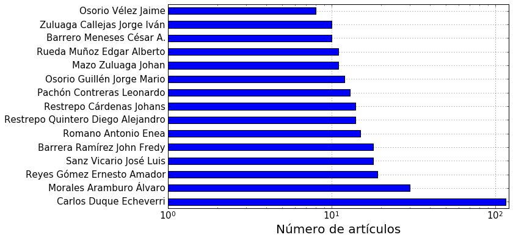

```python
publifull5['UdeA_Author'].value_counts()[:15].plot(kind='barh', rot=0, grid=True)
plt.xlabel(u'Número de artículos',size=20)
plt.xscale('log')
plt.xlim(1,publifull5['UdeA_Author'].value_counts().max()+5)
```

### Conclusión

Se alcanza a notar algo del relevo generacional

## Resultados por citaciones a los artículos

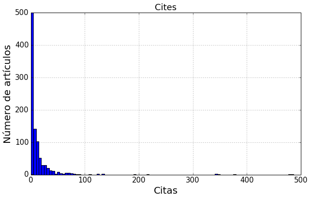

```python
publicadas[['Cites']].hist(bins=100)
#plt.ylabel(u'Número de artículos',size=20)
plt.xlabel(u'Citas',size=20)
plt.ylabel(u'Número de artículos',size=20)
```

#### Global

Incluye el índice h [https://en.wikipedia.org/wiki/H-index]: h publicaciones tienen al menos h Citas

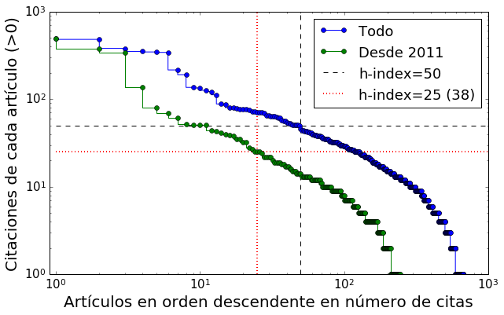

```python
def h_index(x,y):
    '''h-index as in https://en.wikipedia.org/wiki/H-index
    {1:10,2:8,3:5,4:4,5:3} -> 4
    {1:25,2:8,3:5,4:3,5:3} -> 3
    '''
    ax=np.asarray(x)
    ay=np.asarray(y)
    if np.abs(ax-ay).min()<=2:
        h=ay[np.abs(ax-ay)==np.abs(ax-ay).min()]
    else: #od the difference is large, depart from wikipedia and take conservative value
        h=ax[np.abs(ax-ay)==np.abs(ax-ay).min()]
    if h.shape[0]!=0:
        return h[0]
    else:
        return -1

y=publicadas.sort_values(by='Cites',ascending=False).reset_index(drop=True).Cites
x=np.asarray(y.index+1)
h=h_index(x,y)
plt.hlines(h,1,1000,linestyles='dashed',label='h-index=%d' %h)
plt.vlines(h,1,1000,linestyles='dashed')
plt.step(x,y,'bo',lw=1,label='Todo')

y=publicadas5.sort_values(by='Cites',ascending=False).reset_index(drop=True).Cites
x=np.asarray(y.index+1)
h=h_index(x,y)
plt.hlines(h,1,1000,linestyles='dotted',lw=2,colors='r',label='h-index=%d (38)' %h)
plt.vlines(h,1,1000,linestyles='dotted',lw=2,colors='r')
plt.step(x,y,'go',lw=1,label='Desde %d' %publicadas5.Year.min())
plt.xscale('log')
plt.yscale('log')
plt.legend(loc='best')

plt.xlim(1-0.1)
plt.legend(loc='best')
plt.xlabel(u'Artículos en orden descendente en número de citas',size=20)
plt.ylabel(u'Citaciones de cada artículo (>0)',size=20)
```

En perfil en Google Scholar: de TODAS las publicaciones, 38 publicaciones han alcanzado 38 citas en los últimos cinco años

```python
publicadas.sort_values(by='Cites',ascending=False).reset_index(drop=True)[:10][\
                    ['Year','Publication','First_UdeA_Author','Cites']]
```

|  | Year | Publication | First_UdeA_Author | Cites |
| --- | --- | --- | --- | --- |
| 0 | 2014 | Journal of High Energy Physics | José David Ruíz Álvarez | 487 |
| 1 | 2008 | Physics Reports | Nardi Enrico | 480 |
| 2 | 2014 | Journal of High Energy Physics | José David Ruíz Álvarez | 379 |
| 3 | 2010 | Nature | Sanz Vicario José Luis | 350 |
| 4 | 2006 | Journal of High Energy Physics | Nardi Enrico | 345 |
| 5 | 2014 | Physical Review D | José David Ruíz Álvarez | 341 |
| 6 | 1980 | Physical Review D | Ponce Gutiérrez William Alberto | 215 |
| 7 | 2009 | Journal of Cosmology and Astroparticle Physics | Nardi Enrico | 190 |
| 8 | 2014 | Physics Letters B | José David Ruíz Álvarez | 136 |
| 9 | 2004 | Physical Review B | Morales Aramburo Álvaro | 134 |

#### Por Grupos histórico

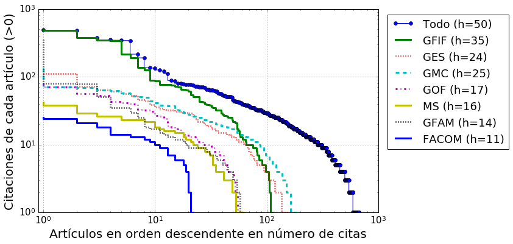

```python
y=publicadas.sort_values(by='Cites',ascending=False).reset_index(drop=True).Cites
x=np.asarray(y.index+1)
plt.step(x,y,'bo',lw=1,label='Todo (h=%d)' %h_index(x,y))
plt.xscale('log')
plt.yscale('log')


for G in ['GFIF','GES','GMC','GOF','MS','GFAM','FACOM']:
    y=publicadas[publicadas.Grupo.str.contains(G)].sort_values(by='Cites',\
                            ascending=False).reset_index(drop=True).Cites
    x=np.asarray(y.index+1)

    plt.loglog(x,y,s[G],lw=3,drawstyle='steps',label='%s (h=%d)' %(G,h_index(x,y)))

plt.legend(loc='upper right',bbox_to_anchor=(1.4, 1))
plt.xlim(1-0.1)
plt.xlabel(u'Artículos en orden descendente en número de citas',size=20)
plt.ylabel(u'Citaciones de cada artículo (>0)',size=20)
plt.grid()
```

#### Por Grupos últimos 5 años

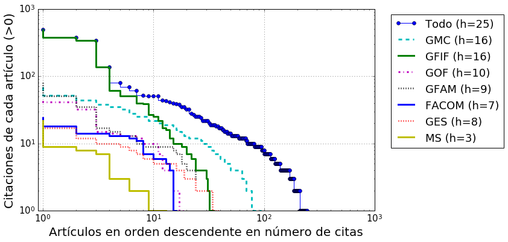

```python
y=publicadas5.sort_values(by='Cites',ascending=False).reset_index(drop=True).Cites
x=np.asarray(y.index+1)
plt.step(x,y,'bo',lw=1,label='Todo (h=%d)' %h_index(x,y))
plt.xscale('log')
plt.yscale('log')


for G in ['GMC','GFIF','GOF','GFAM','FACOM','GES','MS']:
    y=publicadas5[publicadas5.Grupo.str.contains(G)].sort_values(by='Cites',\
                            ascending=False).reset_index(drop=True).Cites
    x=np.asarray(y.index+1)

    plt.loglog(x,y,s[G],lw=3,drawstyle='steps',label='%s (h=%d)' %(G,h_index(x,y)))

plt.legend(loc='upper right',bbox_to_anchor=(1.4, 1))
plt.xlim(1-0.1)
plt.xlabel(u'Artículos en orden descendente en número de citas',size=20)
plt.ylabel(u'Citaciones de cada artículo (>0)',size=20)
plt.grid()
```

GFIF: 5 artículos en CMS que en realidad son 10 (h-> 21)

#### Indidual histórico

Sólo publicaciones UdeA

```python
ah=pd.DataFrame()
for a in publifull.UdeA_Author.unique():
    y=publifull[publifull.UdeA_Author==a].sort_values(by='Cites',ascending=False).reset_index(drop=True).Cites
    x=np.asarray(y.index+1)
    h=h_index(x,y)
    ah=ah.append({'Author':a,'Cites':y.sum(),'h-index':h},ignore_index=True)

ah[ah['h-index']>0].sort_values(by=['h-index','Cites'],ascending=False).reset_index(drop=True)
```

|  | Author | Cites | h-index |
| --- | --- | --- | --- |
| 0 | Carlos Duque Echeverri | 2513 | 25 |
| 1 | Ponce Gutiérrez William Alberto | 1242 | 17 |
| 2 | Barrero Meneses César A. | 927 | 17 |
| 3 | Morales Aramburo Álvaro | 1023 | 16 |
| 4 | Restrepo Quintero Diego Alejandro | 672 | 16 |
| 5 | Restrepo Cárdenas Johans | 600 | 16 |
| 6 | Barrera Ramírez John Fredy | 677 | 15 |
| 7 | Nardi Enrico | 1723 | 14 |
| 8 | Reyes Gómez Ernesto Amador | 432 | 14 |
| 9 | Henao Henao Rodrigo | 513 | 11 |
| 10 | Mazo Zuluaga Johan | 243 | 11 |
| 11 | Sanz Vicario José Luis | 709 | 10 |
| 12 | Zapata Noreña Oscar | 258 | 10 |
| 13 | Pachón Contreras Leonardo | 187 | 9 |
| 14 | Zuluaga Callejas Jorge Iván | 155 | 9 |
| 15 | Romano Antonio Enea | 163 | 7 |
| 16 | Mira Agudelo Alejandro | 161 | 7 |
| 17 | Rueda Muñoz Edgar Alberto | 159 | 7 |
| 18 | Girata Doris | 151 | 7 |
| 19 | Osorio Vélez Jaime | 150 | 7 |
| 20 | Rodríguez Rey Boris Anghelo | 105 | 7 |
| 21 | Osorio Guillén Jorge Mario | 200 | 6 |
| 22 | Arnache Olmos Óscar L. | 87 | 6 |
| 23 | Mahecha Gómez Jorge E. | 75 | 6 |
| 24 | José David Ruíz Álvarez | 1368 | 5 |
| 25 | Páez Manuel | 68 | 5 |
| 26 | Ferrín Vázquez Ignacio R. | 17 | 5 |
| 27 | Silva Villa Esteban | 41 | 4 |
| 28 | Giraldo Cadavid Marco A. | 50 | 3 |
| 29 | Muñoz Cuartas Juan Carlos | 31 | 3 |
| 30 | Wu Huachuan | 20 | 3 |
| 31 | Jaramillo Arango Daniel E. | 18 | 2 |
| 32 | Mira Martínez Jesús María | 30 | 1 |
| 33 | Valencia Valencia José Patricio | 7 | 1 |
| 34 | Cuartas Restrepo Pablo | 5 | 1 |
| 35 | Tobón Gómez Jorge Enrique | 4 | 1 |

#### Individual últimos cinco años

Sólo publicaciones UdeA

```python
ah=pd.DataFrame()
for a in publifull5.UdeA_Author.unique():
    y=publifull5[publifull5.UdeA_Author==a].sort_values(by='Cites',ascending=False).reset_index(drop=True).Cites
    x=np.asarray(y.index+1)
    h=h_index(x,y)
    ah=ah.append({'Author':a,'Cites':y.sum(),'h-index':h},ignore_index=True)

ah[ah['h-index']>0].sort_values(by=['h-index','Cites'],ascending=False).reset_index(drop=True)
```

|  | Author | Cites | h-index |
| --- | --- | --- | --- |
| 0 | Carlos Duque Echeverri | 896 | 16 |
| 1 | Barrera Ramírez John Fredy | 211 | 10 |
| 2 | Pachón Contreras Leonardo | 187 | 9 |
| 3 | Restrepo Quintero Diego Alejandro | 174 | 9 |
| 4 | Romano Antonio Enea | 163 | 7 |
| 5 | Rueda Muñoz Edgar Alberto | 80 | 7 |
| 6 | Zapata Noreña Oscar | 118 | 6 |
| 7 | Zuluaga Callejas Jorge Iván | 79 | 6 |
| 8 | José David Ruíz Álvarez | 1368 | 5 |
| 9 | Sanz Vicario José Luis | 120 | 5 |
| 10 | Reyes Gómez Ernesto Amador | 67 | 5 |
| 11 | Morales Aramburo Álvaro | 67 | 5 |
| 12 | Osorio Guillén Jorge Mario | 43 | 5 |
| 13 | Ferrín Vázquez Ignacio R. | 17 | 5 |
| 14 | Nardi Enrico | 69 | 4 |
| 15 | Mira Agudelo Alejandro | 69 | 4 |
| 16 | Silva Villa Esteban | 39 | 4 |
| 17 | Mahecha Gómez Jorge E. | 28 | 4 |
| 18 | Ponce Gutiérrez William Alberto | 24 | 4 |
| 19 | Arnache Olmos Óscar L. | 21 | 4 |
| 20 | Rodríguez Rey Boris Anghelo | 13 | 4 |
| 21 | Osorio Vélez Jaime | 10 | 4 |
| 22 | Restrepo Cárdenas Johans | 56 | 3 |
| 23 | Barrero Meneses César A. | 41 | 3 |
| 24 | Muñoz Cuartas Juan Carlos | 31 | 3 |
| 25 | Mazo Zuluaga Johan | 15 | 3 |
| 26 | Cuartas Restrepo Pablo | 5 | 1 |
| 27 | Páez Manuel | 4 | 1 |

### Conclusión:

Sabemos hacer el menú del día, pero...

*¿Como hacer un plato gourmet?*

## Resultados sobre índicadores asociados a las revistas

### Clasificación Colciencias

#### Histórico

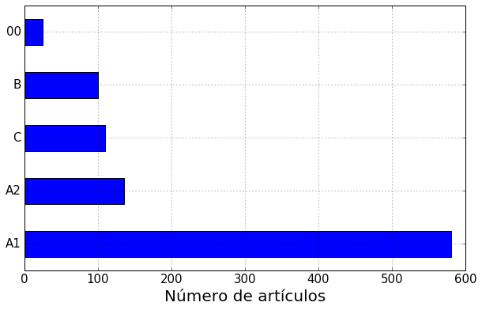

```python
publicadas['Clasificación Colciencias'].value_counts().plot(kind='barh',grid=True)
plt.xlabel(u'Número de artículos',size=20)
```

#### Últimos cinco años

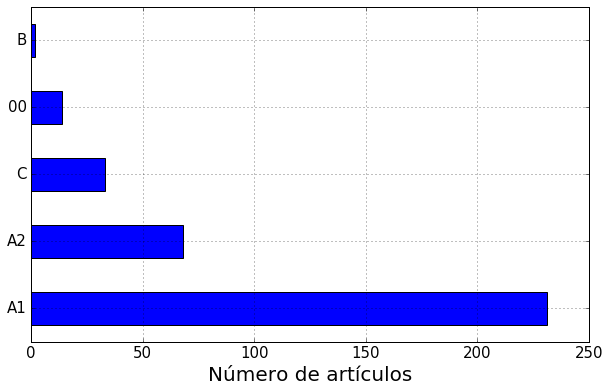

```python
publicadas5['Clasificación Colciencias'].value_counts().plot(kind='barh',grid=True)
plt.xlabel(u'Número de artículos',size=20)
```

## Factor de impacto

### Factor de impacto (FI) en revistas con FI>0

Factor de impacto de los últimos 4 años. Para publicaciones muy antigüas se usa el FI más antigüo

#### Histórico

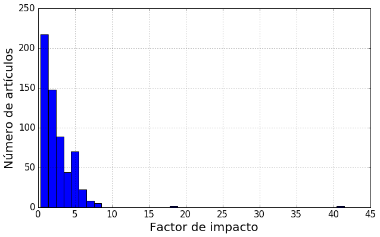

```python
fi=publicadas[['Factor de Impacto']].replace('null',0)
fii=fi[fi['Factor de Impacto']>0].reset_index(drop=True)
fii.astype('float')['Factor de Impacto'].hist(bins=40)
plt.ylabel(u'Número de artículos',size=20)
plt.xlabel(u'Factor de impacto',size=20)
```

Impondremos un corte para facilitar la visualización: FI<15

#### Histórico por Grupos

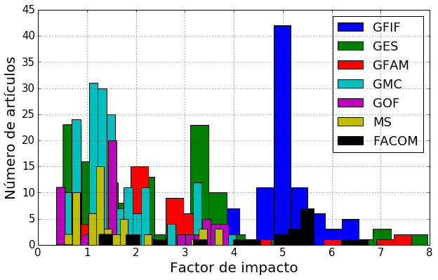

```python
for group in ['GFIF','GES','GFAM','GMC','GOF','MS','FACOM']:
    fi=publicadaslt15[publicadaslt15['Grupo'].str.contains(group)][['Factor de Impacto']].replace('null',0)
    fii=fi[fi['Factor de Impacto']>0].reset_index(drop=True)
    fii.astype('float')['Factor de Impacto'].hist(bins=20,label=group)
    plt.legend(loc='best')
    plt.ylabel(u'Número de artículos',size=20)
    plt.xlabel(u'Factor de impacto',size=20)
```

#### Últimos cinco años Global

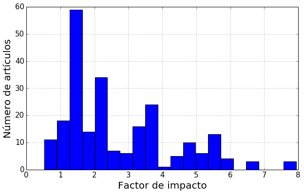

```python
publicadas5['Factor de Impacto']=publicadas5['Factor de Impacto'].replace('Desconocido',-1)
fi=publicadas5[['Factor de Impacto']].replace('null',0)
fii=fi[fi['Factor de Impacto']>0].reset_index(drop=True)
fii.astype('float')['Factor de Impacto'].hist(bins=20)
plt.ylabel(u'Número de artículos',size=20)
plt.xlabel(u'Factor de impacto',size=20)
```

#### Últimos cinco años: por Grupos

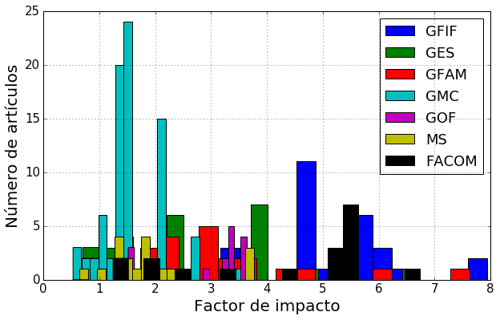

```python
for group in ['GFIF','GES','GFAM','GMC','GOF','MS','FACOM']:
    fi=publicadas5[publicadas5['Grupo'].str.contains(group)][['Factor de Impacto']].replace('null',0)
    fii=fi[fi['Factor de Impacto']>0].reset_index(drop=True)
    fii.astype('float')['Factor de Impacto'].hist(bins=20,label=group)
    plt.legend(loc='best')
    plt.ylabel(u'Número de artículos',size=20)
    plt.xlabel(u'Factor de impacto',size=20)
```

Detalles

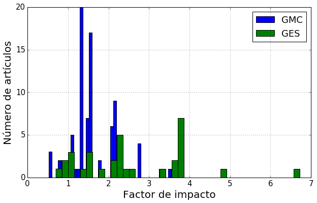

```python
for group in ['GMC','GES']:
    fi=publicadas5[publicadas5['Grupo'].str.contains(group)][['Factor de Impacto']].replace('null',0)
    fii=fi[fi['Factor de Impacto']>0].reset_index(drop=True)
    fii.astype('float')['Factor de Impacto'].hist(bins=40,label=group)
    plt.legend(loc='best')
    plt.ylabel(u'Número de artículos',size=20)
    plt.xlabel(u'Factor de impacto',size=20)
```

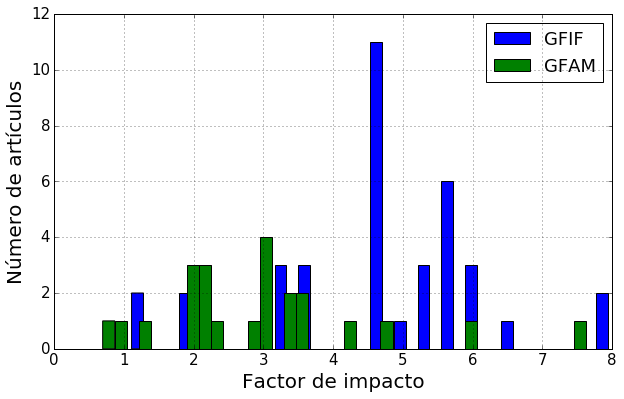

```python
for group in ['GFIF','GFAM']:
    fi=publicadas5[publicadas5['Grupo'].str.contains(group)][['Factor de Impacto']].replace('null',0)
    fii=fi[fi['Factor de Impacto']>0].reset_index(drop=True)
    fii.astype('float')['Factor de Impacto'].hist(bins=40,label=group)
    plt.legend(loc='best')
    plt.ylabel(u'Número de artículos',size=20)
    plt.xlabel(u'Factor de impacto',size=20)
```

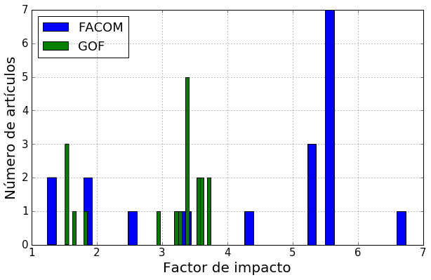

```python
for group in ['FACOM','GOF']:
    fi=publicadas5[publicadas5['Grupo'].str.contains(group)][['Factor de Impacto']].replace('null',0)
    fii=fi[fi['Factor de Impacto']>0].reset_index(drop=True)
    fii.astype('float')['Factor de Impacto'].hist(bins=40,label=group)
    plt.legend(loc='best')
    plt.ylabel(u'Número de artículos',size=20)
    plt.xlabel(u'Factor de impacto',size=20)
```

## Y patentes:

2

## Conclusiones generales

- Una estrategía mínima para mantener la media de publicaciones de los grupos es garantizar el relevo de sus miembros *activos*.
- El número promedio de artículos por año para un teórico *activo* es de 4 artículos (en el caso conservador), y para un experimental *activo* es de 1.
- Los aproximadamente 5 artículos de CMS se notan en los gráficos de citaciones. CMS y ATLAS están produciendo ~100 artículos por año con ~10,000 citaciones. Ver pr ejemplo:

  http://inspirehep.net/search?p=cn+atlas+and+date+2012&of=hcs

  Las grandes colaboraciones impactan fuertemente en cantidad y calidad de artículos.
- En general: el incremento en el impacto de las publicaciones requiere cambios de paradigma.
- Congresos bien establecidos pueden crear incentivos de publicación en estudiantes
- El fortalecimiento del área de astrofísica se ha comenzado a notar en los últimos tres años, tanto en número como en el impacto de las publicaciones.